# Validation of read across predictions for nanoparticle toxicities

Christoph Helma, Micha Rautenberg, Denis Gebele

in silico toxicology gmbh, Basel, Switzerland

[figure not shown]

# Objectives

- Validate `lazar` read across models for nanoparticles
- Compare regression algorithms
  - Local weighted average
  - Local weighted partial least squares
  - Local weighted random forests
- Compare nanoparticle descriptors
  - Nanoparticle properties (physchem, size, shape, ...)
  - Interaction with human serum proteins
- Provide an example for reproducible research

# `lazar` read across framework

- Search in a database for similar nanoparticles (*neighbors*)
- Build a local QSAR model with these neighbors
- Use this model to predict the activity of the query compound

# Similarity calculation

**Relevant features**

Features that correlate significantly with toxicity (Pearson correlation p-value < 0.05)

**Weighted cosine similarity**

- Scaled and centered *relevant feature* vectors
- Feature contributions weighted by Pearson correlation coefficient
- Similarity threshold: *s**i**m* > 0.5

# Local regression algorithms

- Weighted average
- Weighted partial least squares regression
- Weighted random forests

Partial least squares and random forest models use the `caret` R package with default settings

Prediction intervals: 1.96*RMSE of `caret`s bootstrapped model predictions

If PLS/RF modelling or prediction fails, `lazar` resorts to using the weighted average method.

# Validation

- 3 repeated 10-fold crossvalidations with independent training/test set splits
- *No* fixed random seed for training/test set splits, to avoid overfitting and to demonstrate the variability of validation results due to random training/test splits.
- Separate feature selection for each training dataset to avoid overfitting

# Data requirements

- At least 100 examples per toxicity endpoint for statistically meaningful validation results
- At least non-empty intersection of descriptors for calculation of similarities

*Net cell association* endpoint of the *Protein corona* dataset (121 gold and silver particles)

# 10-fold crossvalidations

| Descriptors | Algorithm | *r*<sup>2</sup> | RMSE |  |
| --- | --- | --- | --- | --- |
| Physchem | WA | `0.42, 0.46, 0.48` | `2.02, 1.94, 1.92` |  |
| Physchem | PLS | `0.53, 0.54, 0.49` | `1.83, 1.8, 1.9` |  |
| Physchem | RF | `0.53, 0.52, 0.54` | `1.82, 1.84, 1.79` |  |
| Proteomics | WA | `0.66, 0.63, 0.63 *` | `1.58, 1.62, 1.66 *` |  |
| Proteomics | PLS | `0.59, 0.66, 0.63 *` | `1.74, 1.56, 1.65 *` |  |
| Proteomics | RF | `0.66, 0.65, 0.63 *` | `1.56, 1.59, 1.64 *` |  |
| All | WA | `0.73, 0.66, 0.66 *` | `1.41, 1.57, 1.58 *` |  |
| All | PLS | `0.67, 0.64, 0.69 *` | `1.53, 1.63, 1.5 *` |  |
| All | RF | `0.69, 0.69, 0.7 **` | `1.51, 1.5, 1.46 **` |  |

Gold *and* silver particles included!

# Correlation plot

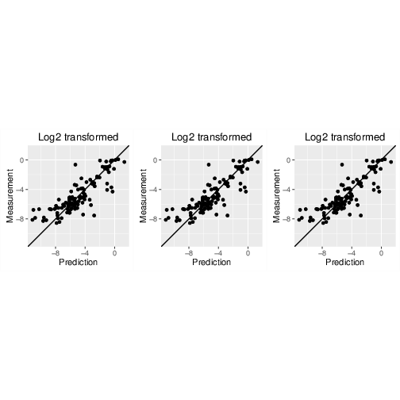

Correlation of log2 transformed net cell association measurements with random forest predictions using physchem properties and protein corona data.

# Reproducible research

- Manuscript (and presentation) including figures and tables are built directly from experimental results
- Custom `pandoc` filter (similar to `knitr` for `R`)
- Simple Makefile (`make clean; make` re-runs all experiments and creates an updated manuscript)

**Lazar (source code)**

https://github.com/opentox/lazar

**Manuscript (source code)**

https://github.com/opentox/nano-lazar-paper

**Docker image**

https://hub.docker.com/r/insilicotox/nano-lazar-paper/

# Questions

# TODO

- Webinar
- Finish and publish paper (journal suggestions?)
- Adjust nano-lazar GUI